# Effects of Professor Performance and Student Behavior on Overall Teaching Evaluation in Marketing Courses at Miami University

**Author**: Rongrong Qian, Richel Attafuah

**Date**: 2025-10-08

# 1 Introduction

Student Evaluations of Teaching (SETs) are key tools used in higher education. They measure teaching quality and instructor performance. Results are often used for faculty reviews, promotions, and decisions about course improvement. Although SETs are used widely, there is much discussion about the specific factors that shape a student’s idea of “Overall Instructor Effectiveness.” Accurately identifying and measuring these factors is important. This ensures evaluations are fair and valid, and it provides information to help improve teaching strategies.

The core statistical goal of this report is to explore the links between specific evaluation metrics and the student’s overall rating of the instructor. The aim is to build a model that explains the sources of variation in “instructor effectiveness” scores. Specifically, this study will focus on three main research questions:

1. The effect of professor performance measures: How much do specific measurements of instructor teaching performance statistically influence the student’s final “overall instructor evaluation”?
2. The effect of student behavior measures: Is there a statistical link between measurements related to student behavior or course engagement and the overall rating they give the instructor?
3. Variation by course type: Do the relationships found in questions 1 and 2 change in a significant way depending on the type of course (for example, a core requirement versus an elective class)?

By answering these questions, this study hopes to provide clear insights to areas of improvements that can be implemented. These results will provide better guidance to enhance course delivery quality.

# 2 Methods

## 2.1 Data

The dataset includes student evaluations from every section of marketing (MKT) courses at Miami University. The data covers the fall and spring semesters from 2013 to 2017. Per the study design, all instructor identifications (InstID) were anonymized, and evaluation data was aggregated by course section.

The dataset contains a moderator variable (Course type), 6 measures of student behavior (prefixed with “s”), and 15 measures of professor performance (prefixed with “i”). For all survey items, any N/A response was coded as -1 and is omitted from all measure calculations.

### 2.1.1 Dependent Variable (Overall Rating)

The primary dependent variable for this analysis is `iRating`. This variable corresponds to the survey question “What is your overall rating of the instructor?”. This item was measured on a five point scale and numerically coded for analysis as follows:

- Unsatisfactory = 0
- Poor = 1
- Average = 2
- Good = 3
- Excellent = 4

### 2.1.2 Professor Performance

The first set of predictors includes 14 measures assessing specific aspects of professor performance. These items were measured on a five point agreement scale, numerically coded as: Strongly Disagree (0), Disagree (1), Neutral (2), Agree (3), and Strongly Agree (4).

The specific variable names and their corresponding survey questions are listed in the table below.

Table1: Labels for Professor Performance Measures

| Measure | Survey_Question |
| --- | --- |
| iStandards | The instructor held students to high academic standards. |
| iChallenged | The instructor effectively challenged me to think and to learn. |
| iPrepared | The instructor was well prepared. |
| iConcepts | Examinations and/or other graded components covered course concepts in a challenging manner. |
| iEnthusiasm | The instructor showed enthusiasm for the subject. |
| iAskQues | I felt free to ask questions and to make comments in class. |
| iQuesEffect | The instructor dealt with questions and comments effectively. |
| iHours | The instructor was generally available during office hours. |
| iRating | What is your overall rating of the instructor? |
| iWelQues | My instructor welcomed students’ questions. |
| iParticipate | My instructor offered opportunities for active participation to understand course content. |
| iDemo | My instructor demonstrated concern for student learning. |
| iAnalyProb | In this course I learned to analyze complex problems or think about complex issues. |
| iTopic | My appreciation for this topic has increased as a result of this course. |
| iUnderstand | I have gained an understanding of this material |

### 2.1.3 Student Behavior

The second set of predictors includes 6 measures assessing specific aspects of student behavior. These items were measured on a five point frequency scale, numerically coded as: Never (0), Rarely (1), Sometimes (2), Often (3), and Always (4).

Table 2: Labels for Student Behavior Measures

| Measure | Survey_Question |
| --- | --- |
| sPositive | I took responsibility for helping to make this course a positive learning experience. |
| sAttended | I attended class. |
| sPrepared | I prepared for class. |
| sEngaged | When I attended class, I was actively engaged. |
| sUpToDate | I stayed up-to-date in the course work. |
| sHelp | I sought help when I needed it. |

### 2.1.4 Moderator Variable (Course Type)

The moderator variable for this analysis is `CourseType`. This categorical variable is coded with four distinct levels representing different marketing course classifications:

- 1 = FSB Core
- 2 = MKT Core
- 3 = MKT Elective
- 4 = MKT Capstone

## 2.2 Statistical Analysis

### 2.2.1 Standardized Scores for Comparison

The variables in this study, such as ‘iRating’ and other teaching items, used different scales. These scales have different anchors and likely different response patterns. This makes their original scores, including their means, not directly comparable. To fix this problem of scale heterogeneity and create a common framework, all professor performance and student behavior variables were standardized. They were converted to standard scores (Z scores) with a mean of 0 and a standard deviation of 1. This change makes it possible to validly interpret and compare the relative effect sizes and standing of all measures.

### 2.2.2 Weight Adjustment

To ensure that evaluation scores based on a larger number of student responses have a greater influence on the overall analysis, a weighting system was applied. This approach accounts for the higher precision and reliability of scores derived from larger samples.

The weight for each course section is determined by the absolute number of students who completed the evaluation.

The initial raw weight for each course section is set as the number of completed evaluations:
$$Raw\ Weight_{i} = Completed_{i} \tag{1}$$

To preserve the correct scale for statistical inference, these raw weights are then normalized so that their sum equals the total number of course sections in the analysis (N). The final weight is calculated as:

$$Weight_{i} = \frac{Raw\ Weight_{i}}{\sum_{j=1}^{N} Raw\ Weight_{j}}
\times N \tag{2}$$
Where:

- $\text{Weight}_i$ is the final normalized weight for course section i.
- $\text{Completed}_i$ is the number of students who completed the evaluation for course section i.
- $N$ is the total number of course sections included in the analysis.

### 2.2.3 Multicollinearity

Before fitting any models, multicollinearity among the predictor variables needs to be accessed using Variance Inflation Factor (VIF) analysis. High VIF values (commonly above 5 or 10) indicate that a predictor is highly correlated with other predictors, which can inflate standard errors and make coefficient estimates unstable. If multicollinearity is detected, **random forest** modeling will be considered as a strategy to assess variable importance, as it is less sensitive to multicollinearity issues. However, random forest regression does not solve the multicollinearity problem, it only mitigates its impact on variable importance measures.

The **conceptual grouping method** was considered to reduce multicollinearity by combining correlated predictors into composite scores based on theoretical constructs. This approach simplifies the model and reduces redundancy among predictors.

### 2.2.4 Independence

A series of **hierarchical linear mixed effects models** was used to analyze the data, accounting for course sections nested within instructors. The baseline model included random intercepts and random slopes for instructors. Then sequentially added blocks of predictors: first student behavior variables, followed by course type, and finally their interaction terms. Each step was evaluated using Likelihood Ratio Tests (LRTs) to assess significant improvements in model fit. All models were fit with maximum likelihood (ML) for comparison, and the final selected model was estimated using restricted maximum likelihood (REML) for parameter reporting.

### 2.2.5 Model 1: Weighted Two Level Random Effects Model (Instructor-only, random intercept)

To estimate average effects of instructor performance while accounting for sections nested within instructors and participation-rate weights:

$$iRating_{ij} = \beta_0 + \sum_{k=1}^{K} \beta_k X_{ijk} + u_j +
\epsilon_{ij} \tag{2}$$
Where:

- $iRating_{ij}$ is the overall instructor rating for course section $i$ taught by instructor $j$.
- $\beta_0$ is the overall intercept.
- $\beta_k$ are the fixed effect coefficients for the $K$ standardized predictor variables $X_{ijk}$ (professor performance and student behavior measures).
- $u_j$ is the random effect for instructor $j$, capturing unobserved heterogeneity among instructors.
- $\epsilon_{ij}$ is the residual error term for course section $i$ taught by instructor $j$.

Constrains:

- $u_j$ ~ N(0, $\sigma_u^2$))
- $\epsilon_{ij}$ ~ N(0, $\sigma_{\epsilon}^2$))
- $u_j$ and $\epsilon_{ij}$ are assumed to be independent.

### 2.2.6 Model 1-2: Weighted Two Level Random Effects Model (Instructor-only, random intercept + random slopes)

To assess if the effects of key professor performance measures vary by instructor, random slopes were added for selected predictors:

$$iRating_{ij} = \beta_0 + \sum_{k=1}^{K} \beta_k X_{ijk} + u_j +
\sum_{m=1}^{M} v_{jm} X_{ijm} + \epsilon_{ij} \tag{2.1}$$

Where:

- $v_{jm}$ are the random slope effects for selected $M$ predictors
- $X_{ijm}$, allowing their effects to vary by instructor $j$.
- Other terms as in Model 1.

Constraints:

- $v_{jm}$ ~ N(0, $\sigma_v^2$))
- $v_{jm}$ are assumed to be independent of $u_j$ and $\epsilon_{ij}$.

### 2.2.7 Model 2: Weighted Two Level Random Effects Model (+ Student Behavior Block)

Add student behavior measures to assess incremental explanatory value beyond instructor measures:

$$iRating_{ij} = \beta_0 + \sum_{k=1}^{K} \beta_k X_{ijk} + \sum_{l=1}^{L}
\beta_l S_{ijl} + u_j + \epsilon_{ij} \tag{3}$$
Where:

- $S_{ijl}$ are the $L$ standardized student behavior measures for course section $i$ taught by instructor $j$.
- Other terms as in Model 1.

### 2.2.8 Model 3: Weighted Two Level Random Effects Model (+ Course Type Main Effects)

Add course type indicators to control for systematic differences across types:

$$iRating_{ij} = \beta_0 + \sum_{k=1}^{K} \beta_k X_{ijk} + \sum_{l=1}^{L}
\beta_l S_{ijl} + \gamma_j C_{j} + u_j + \epsilon_{ij} \tag{4}$$
Where:

- $C_{j}$ is the vector of CourseType dummies for instructor j’s section (e.g., FSB Core, MKT Core, MKT Elective, MKT Capstone; one omitted as reference).
- Other terms as in Model 1.

### 2.2.9 Model 4: Weighted Two-Level Random Effects with Course Type (Interactions)

To test if the effects of professor performance and student behavior measures vary by course type, interaction terms were added:

$$iRating_{ij} = \beta_0 + \sum_{k=1}^{K} \beta_k X_{ijk} + \sum_{l=1}^{L}
\beta_l S_{ijl} + \gamma_j C_{j} + \delta_{I} (X_{ij} * C_{j}) +
\theta_{S} (S_{ij} * C_{J}) + u_j + \epsilon_{ij} \tag{5}$$
Where:

- $\delta_{I}$ are the coefficients for the interaction terms between professor performance measures $X_{ijk}$ and course type $C_{j}$.
- $\theta_{S}$ are the coefficients for the interaction terms between student behavior measures $S_{ijl}$ and course type $C_{j}$.
- Other terms as in Model 1.

The coefficients $\delta_{I}$ and $\theta_{S}$ will be tested for significance to determine if the relationships between the predictors and overall instructor rating differ by course type.

## 2.3 Software

All statistical analyses and data visualizations were performed using the `R (version 4.5.1)` within the `RStudio` integrated development environment (version 2025.05.0).

The analytical workflow relied on a suite of specialized packages. Data manipulation and transformation were conducted using the `tidyverse` ecosystem, including core packages like `dplyr` and `tidyr`. Statistical modeling was primarily accomplished with the `lmerTest` package for fitting and evaluating linear mixed-effects models. The `car` package was used for model diagnostics, such as checking for multicollinearity.

For data visualization, `ggplot2` was used to create primary plots, `corrplot` was employed for correlation matrices, and `cowplot` helped arrange final figures. Finally, the `knitr` and `kableExtra` packages were utilized to generate reproducible reports and format high-quality tables.

# 3 Results

## 3.1 Exploratory Data Analysis Results

### 3.1.1 Distribution of Overall Instructor Rating (iRating)

The best measure of overall instructor effectiveness is the `iRating` variable. This variable captures the student’s holistic evaluation of their instructor. The distribution of `iRating` across all course sections is shown in the histogram below.

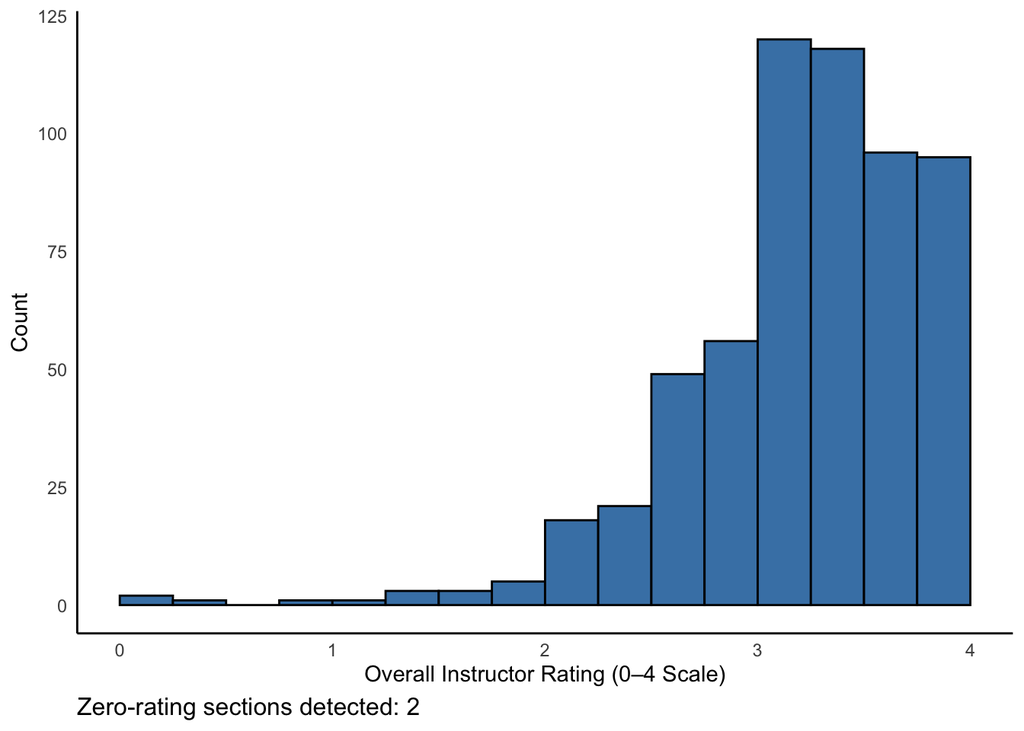

Figure 1: Distribution of Overall Instructor Ratings (iRating).

Table 3: Audit of iRating = 0 sections (check data quality/context)

| Term | CourseType | Enrolled | Completed | Participation | iRating |
| --- | --- | --- | --- | --- | --- |
| 201420 | MKT Capstone | 38 | 0 | 0 | 0 |
| 201620 | MKT Capstone | 25 | 0 | 0 | 0 |

Figure 1 shows the distribution of overall instructor ratings (iRating) across all course sections. The majority of ratings cluster between 3 and 4, corresponding to the categories “Good” and “Excellent,” which indicates that students generally provide favorable evaluations of their instructors. A smaller number of responses fall below 2, but these are relatively rare. Notably, **two outlier scores of 0 (shown in Table 3) were identified as technical artifacts and were excluded** from the analysis to ensure the integrity of the results.

### 3.1.2 Participation rate by instructor(InstID)

Participation rate is calculated as the number of students who completed the evaluation divided by the total number of students enrolled in the course section. Each instructor (InstID) may teach multiple sections, so the average participation rate across all sections taught by each instructor were calculated.

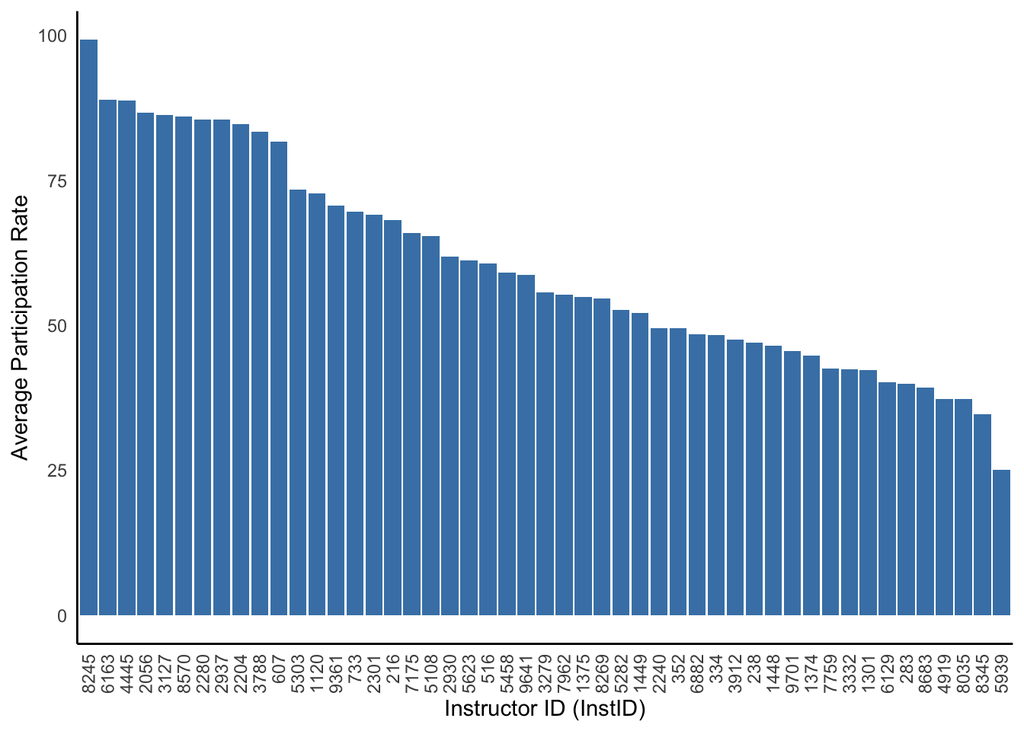

Figure 2: Average Participation Rate by Instructor (InstID).

Figure 2 illustrates significant variability in participation rates among instructors, which range from below 50% to nearly 100%. This variation impacts the representativeness of the evaluation data. Instructors with **low participation rates** need to be **assigned small weights** to the evaluation results, as they may not accurately represent the views of the entire class. Conversely, instructors with high participation rates can be more confident that their evaluation scores reflect a broader range of student opinions.

### 3.1.3 Descriptive Statistics

The descriptive statistics table below provides a summary of the central tendency and dispersion for each professor performance and student behavior measure.

Table 4: Descriptive Statistics for Professor Performance and Student Behavior Measures

| Measure | mean | sd | median | min | max |
| --- | --- | --- | --- | --- | --- |
| iStandards | 3.45 | 0.37 | 3.50 | 0 | 4 |
| iChallenged | 3.32 | 0.47 | 3.38 | 0 | 4 |
| iPrepared | 3.38 | 0.50 | 3.48 | 0 | 4 |
| iConcepts | 3.34 | 0.43 | 3.41 | 0 | 4 |
| iEnthusiasm | 3.57 | 0.40 | 3.67 | 0 | 4 |
| iAskQues | 3.44 | 0.47 | 3.56 | 0 | 4 |
| iQuesEffect | 3.29 | 0.55 | 3.43 | 0 | 4 |
| iHours | 3.45 | 0.51 | 3.57 | 0 | 4 |
| iRating | 3.19 | 0.56 | 3.27 | 0 | 4 |
| iWelQues | 3.54 | 0.45 | 3.67 | 0 | 4 |
| iParticipate | 3.48 | 0.44 | 3.58 | 0 | 4 |
| iDemo | 3.43 | 0.45 | 3.52 | 0 | 4 |
| iAnalyProb | 3.23 | 0.54 | 3.32 | 0 | 4 |
| iTopic | 3.19 | 0.56 | 3.31 | 0 | 4 |
| iUnderstand | 3.31 | 0.51 | 3.41 | 0 | 4 |
| sPositive | 3.53 | 0.30 | 3.55 | 0 | 4 |
| sAttended | 3.78 | 0.31 | 3.82 | 0 | 4 |
| sPrepared | 3.50 | 0.32 | 3.50 | 0 | 4 |
| sEngaged | 3.31 | 0.40 | 3.33 | 0 | 4 |
| sUpToDate | 3.67 | 0.32 | 3.70 | 0 | 4 |
| sHelp | 3.30 | 0.36 | 3.31 | 0 | 4 |

Table 4 shows several key observations:

**The low mean and large standard deviation of instructor ratings reflect the subjective and diverse evaluations of teaching quality by students as consumers, as well as the complexity of teaching itself.**

**The high mean and small standard deviation of student self ratings reflect the widespread self serving bias, where people tend to give themselves a positive evaluation to maintain their self identity.**

### 3.1.4 Average Overall Rating by Course Type

The overall instructor rating (iRating) not only varies by professor performance and student behavior but also shows differences across course types. The table and box plot below summarize the average iRating for each course type.

Table 5: Overall Instructor Rating (iRating) by Course Type — count, mean, and SD

| CourseType | n | mean_iRating | sd_iRating |
| --- | --- | --- | --- |
| MKT Elective | 114 | 3.32 | 0.50 |
| MKT Capstone | 63 | 3.22 | 0.89 |
| FSB Core | 183 | 3.16 | 0.45 |
| MKT Core | 229 | 3.14 | 0.56 |

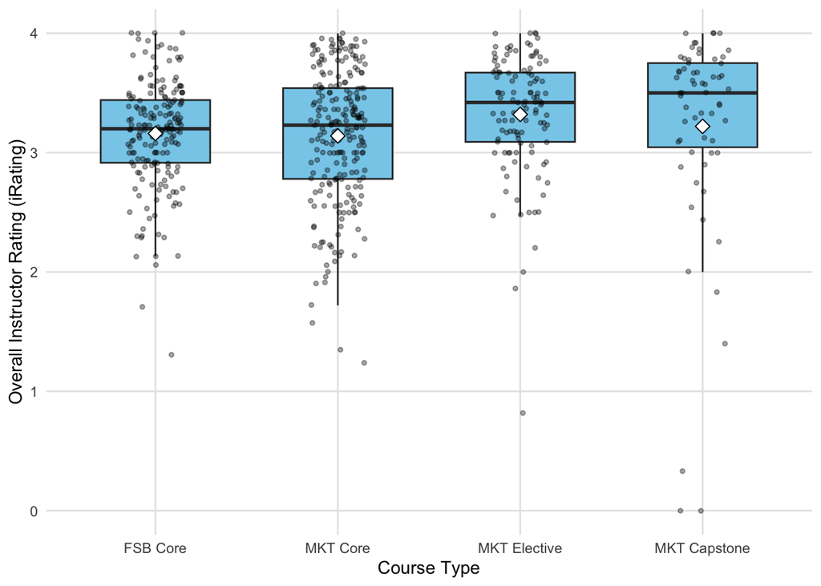

Figure 3: Box Plot of Overall Instructor Rating (iRating) by Course Type.

Table 5 and Figure 3 showed the distribution of overall instructor ratings (iRating) across the four course types. Sample sizes of each course type are large, ranging from 63 to 229 sections, which provides a solid basis for comparison.

- **MKT Elective Courses**

Elective courses received the highest average rating (Mean=3.32,SD=0.50). This result supports a self selection hypothesis: when students choose courses that match their personal interests, they tend to show higher engagement and give more positive evaluations.

- **Required Courses**

In contrast, the two types of required courses, **FSB Core** (Mean=3.16,SD=0.45) and **MKT Core** (Mean=3.14,SD=0.56), received the lowest average ratings. This suggests the mandatory nature of the courses, the student population (some may lack internal interest), and different workload expectations may combine to produce more critical assessments.

- **Capstone Courses**

Capstone courses (Mean=3.22,SD=0.89) present a special situation. First, this mean was significantly lowered by two extreme outliers (an irating of 0 due to 0% completion), which suggests the true mean is likely higher. Second, this course type has the largest standard deviation (SD=0.89), reflecting great variability in student experiences. This may be due to the advanced, complex nature of the course, such as difficult team projects. This intense structure might create both highly positive and frustrating experiences, leading to polarized ratings.

### 3.1.5 Average Rating by Term

The overall instructor rating (iRating) may also vary by academic term (semester). The table and line plot below summarize the average iRating for each term.

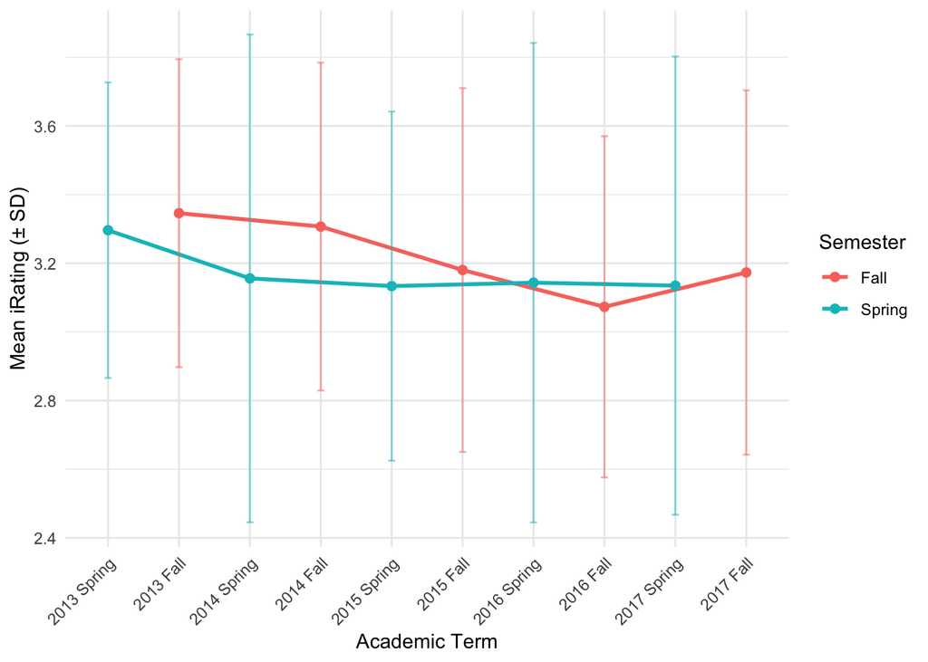

Figure 4: Line Plot of Overall Instructor Rating (iRating) by Term.

The observed decline and subsequent recovery in Fall ratings may be linked to changes in the course portfolio (e.g., a higher proportion of foundational or challenging courses offered in Fall), instructor turnover, or curriculum adjustments that were implemented and stabilized after 2016.

### 3.1.6 Interaction of Course Type and Term

The interaction between course type and academic term may also influence the overall instructor rating (iRating). The line plot below visualizes the mean iRating for each course type across different terms.

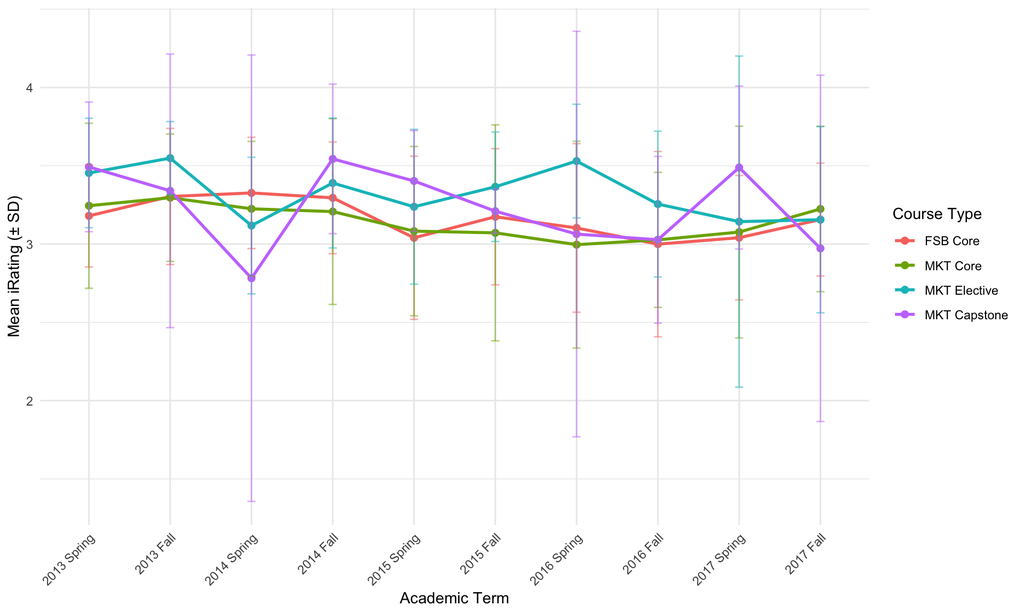

Figure 5: Interaction Plot of Overall Instructor Rating (iRating) by Course Type and Term.

Figure 5 displays the mean instructor ratings (iRatings) by course type and academic term. While mean ratings for most course types are clustered between 3.0 and 3.5, their trajectories suggest a potential **interaction effect**. The most notable pattern is the high volatility of MKT Capstone ratings compared to the relative stability of other course types. However, the wide and overlapping standard deviation bars indicate that many observed differences between course types within a given term may not be statistically significant. Furthermore, the instability in the MKT Capstone series could be an artifact of a small sample size.

### 3.1.7 Scatter plots

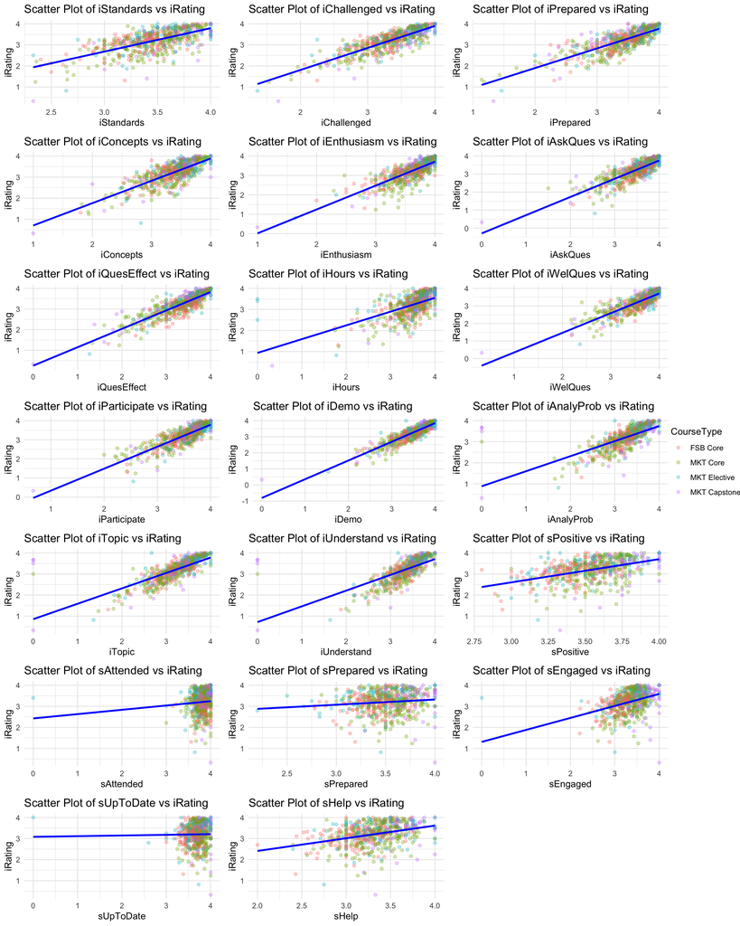

Figure 6: Scatter Plots of All Professor Performance and Student Behavior Measures versus Overall Instructor Rating (iRating), with Points Colored by Course Type and Overall Linear Model Fit.

### 3.1.8 Correlation Analysis

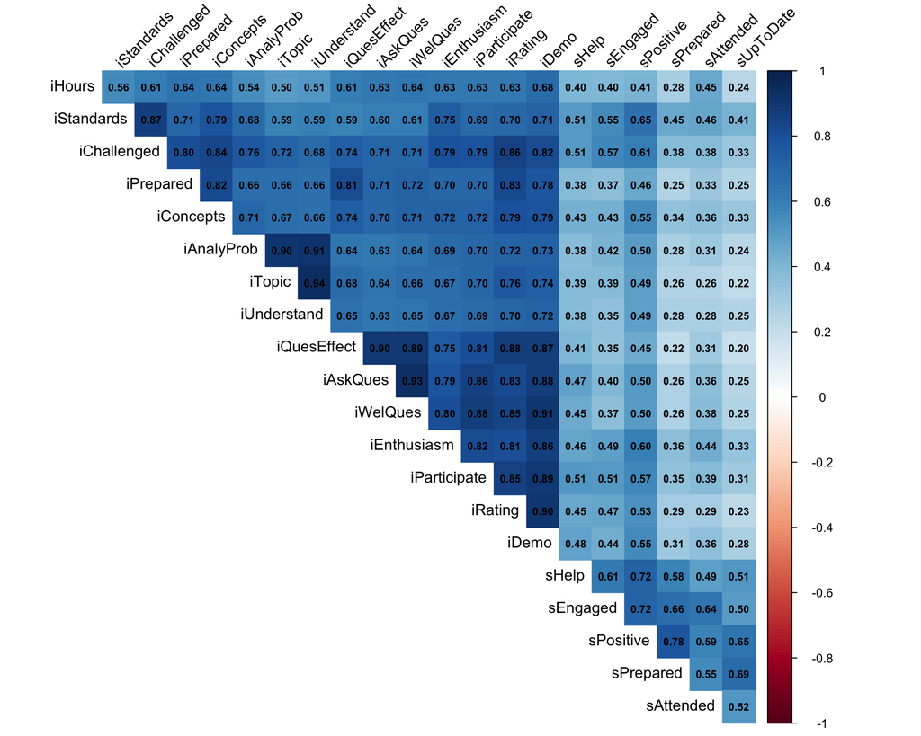

Figure 7: Heat Map of Correlation Matrix for Professor Performance and Student Behavior Measures

From the correlation heat map in Figure 7, we can observe several key patterns:

**The instructor items are highly redundant. To avoid multicollinearity, a composite or dimension reduction approach needs to be considered.**

**Student behavior appears to be a related but distinct construct, contributing more modestly to iRating.**

## 3.2 Random Forest Regression (For Feature Importance)

The random forest used **1,000 trees** to find the best predictors of *iRating* from the full set of `i*` and `s*` survey items plus `CourseType`.

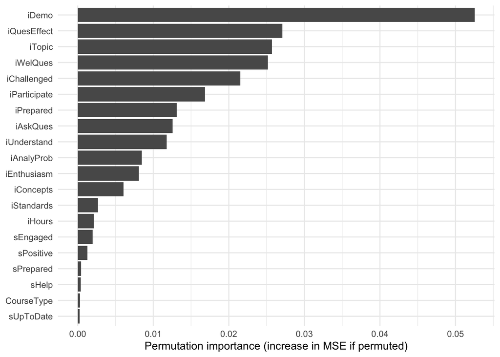

Figure 8: Top 20 Predictors of iRating (Random Forest, Permutation Importance).

These top 10 predictors are all instructor performance items, highlighting their dominant role in shaping overall ratings.

For student behavior, **sEngaged** (student engagement) and **sPositive** (positive attitude) also appear in the top 20, indicating they also contribute meaningfully but to a lesser extent.

## 3.3 Multicollinearity Control via Conceptual Grouping

Instructor items are numerous and conceptually overlapping. Treating many highly correlated items as separate predictors inflates standard errors and blurs interpretation.

Therefore a two-stage strategy was designed to

- Control multicollinearity
- Retain interpretability at the construct level

### 3.3.1 Stage 1: Standardize and diagnose collinearity.

All professor performance items were standardized to zero mean and unit variance so their scales are comparable.

Table 6: Item level VIFs for standardized professor items

| Variable | VIF | Flag |
| --- | --- | --- |
| iUnderstand | 12.57 | High |
| iWelQues | 12.57 | High |
| iDemo | 11.70 | High |
| iTopic | 11.58 | High |
| iAskQues | 10.03 | High |
| iChallenged | 9.89 | Moderate |
| iQuesEffect | 9.49 | Moderate |
| iAnalyProb | 9.07 | Moderate |
| iParticipate | 7.27 | Moderate |
| iStandards | 5.90 | Moderate |
| iPrepared | 5.30 | Moderate |
| sPositive | 5.19 | Moderate |
| iEnthusiasm | 5.16 | Moderate |
| iConcepts | 4.98 | Acceptable |
| sPrepared | 3.37 | Acceptable |
| sEngaged | 3.33 | Acceptable |
| sHelp | 2.38 | Acceptable |
| iHours | 2.34 | Acceptable |
| sAttended | 2.32 | Acceptable |
| sUpToDate | 2.16 | Acceptable |

From Table 6, even after standardization, the multicollinearity issues among the professor performance items are still severe. Other method was needed to solve this problem.

### 3.3.2 Stage 2: Conceptual Grouping

- **Questions Climate**: iWelQues, iAskQues, iQuesEffect
- **Instructor Quality**: iUnderstand, iTopic, iDemo, iAnalyProb
- **Engagement**: iParticipate
- **Intellectual Challenge**: iChallenged
- **Instructor Preparedness**: iPrepared

Table 7: Construct-level collinearity (VIF) after conceptual grouping

| Variable | VIF |
| --- | --- |
| Participate_Z | 5.712 |
| Ques_Z | 5.629 |
| Chall_Z | 4.465 |
| InstrQual_Z | 3.796 |
| Prep_Z | 3.728 |

Table 7 shows the VIFs for the five constructs are all below 6, indicating that conceptual grouping has effectively mitigated multicollinearity among professor performance measures. This allows us to include these constructs as predictors in regression models without severe collinearity issues.

## 3.4 Hypothesis Testing

Based on the results of model comparison (Table 17 in Appendix) of the random intercept model (model 1, m1_ML) and the random intercept and slope model (model 1-2, m1_random_slope_ML), the random intercept and slope model did significantly improve fit over the random intercept model (p < 0.001). Therefore, the random intercept and slope model will be used as the baseline for subsequent models.

Table 8: Model Comparison via Likelihood Ratio Tests

|  | npar | AIC | BIC | logLik | -2*log(L) | Chisq | Df | Pr(>Chisq) |
| --- | --- | --- | --- | --- | --- | --- | --- | --- |
| m1_random_slope_ML | 29 | -360.3120 | -233.3376 | 209.1560 | -418.3120 | NA | NA | NA |
| m2_ML | 31 | -365.6692 | -229.9380 | 213.8346 | -427.6692 | 9.357187 | 2 | 0.0092921 |
| m3_ML | 34 | -357.8281 | -208.9616 | 212.9141 | -425.8281 | 0.000000 | 3 | 1.0000000 |
| m4_ML | 55 | -356.9279 | -116.1144 | 233.4639 | -466.9279 | 41.099736 | 21 | 0.0054499 |

A series of nested linear mixed-effects models was compared using Likelihood Ratio Tests (LRT) to address the specified research questions. The goal of this procedure was not to select a single optimal model for prediction, but rather to test the significance of specific variable sets.

**From model 1 to model 2, adding student behavior measures (sEngaged_Z and sPositive_Z) did significantly improve fit (p-value = 0.0092), indicating that after accounting for professor performance, these student behaviors explain additional variance in overall ratings.**

**From model 2 to model 3, adding CourseType not significantly improved fit (p-value = 1), suggesting that after accounting for professor performance and student behavior, CourseType does not explain additional variance in overall ratings.**

**From model 3 to model 4, adding interaction terms between CourseType and all professor performance and student behavior measures significantly improved fit (p-value = 0.0054). This indicates that the effects of professor performance and student behavior on overall ratings vary by CourseType.**

## 3.5 Results Interpretation

### 3.5.1 Effects of Professor Performance

Model 1-2 assessed the main effects of professor performance measures. Instructor quality (InstrQual_Z), course challenge (Chall_Z), preparation (Prep_Z), and handling of questions (Ques_Z) were all highly significant, which means that better performance on these constructs is associated with higher overall ratings (iRating).

The significant effects of professor performance measures and condifidence intervals are shown in Table 9.

Table 9: Significant Fixed Effects Estimates with 95% CI for Model 1-2

| Term | Estimate | CI_Lower | CI_Upper | t_value | p_value | Significance |
| --- | --- | --- | --- | --- | --- | --- |
| (Intercept) | 3.173 | 3.148 | 3.198 | 247.505 | 0e+00 | *** |
| InstrQual_Z | 0.206 | 0.148 | 0.264 | 6.962 | 0e+00 | *** |
| Chall_Z | 0.084 | 0.040 | 0.129 | 3.714 | 2e-04 | *** |
| Prep_Z | 0.104 | 0.065 | 0.144 | 5.155 | 0e+00 | *** |
| Ques_Z | 0.186 | 0.129 | 0.243 | 6.425 | 0e+00 | *** |

(The whole result of model 1-2 is shown in Appendix Table 18.)

### 3.5.2 Effects of Student Behavior

Table 10: Fixed Effects Estimates with 95% CI for Student Behavior Measures in Model 2

| Term | Estimate | CI_Lower | CI_Upper | t_value | p_value | Significance |
| --- | --- | --- | --- | --- | --- | --- |
| sEngaged_Z | 0.022 | -0.0020001 | 0.0459155 | 1.796 | 0.0724 | . |
| sPositive_Z | 0.018 | -0.0073000 | 0.0437535 | 1.399 | 0.1617 |  |

(The whole result of model 2 is shown in Appendix Table 19.)

### 3.5.3 Effects of Course Type

Table 11: Fixed Effects Estimates with 95% CI for CourseType in Model 3

| Term | Estimate | CI_Lower | CI_Upper | t_value | p_value | Significance |
| --- | --- | --- | --- | --- | --- | --- |
| CourseTypeMKT Core | 0.024 | -0.0166386 | 0.0649999 | 1.161 | 0.2456 |  |
| CourseTypeMKT Elective | -0.021 | -0.0747195 | 0.0334126 | -0.749 | 0.4540 |  |
| CourseTypeMKT Capstone | 0.055 | -0.0231036 | 0.1340429 | 1.384 | 0.1665 |  |

Table 11 showed that CourseType was not significant in model 3, confirming the previous result. Which means that **after accounting for professor performance and student behavior, CourseType was not a significant predictor of overall ratings.**

(The whole result of model 3 is shown in Appendix Table 20.)

### 3.5.4 Effects of Interaction between Course Type and Professor Performance/Student Behavior

Table 12: Fixed Effects Estimates with 95% CI for Key Terms in Model 4

| Term | Estimate | CI_Lower | CI_Upper | t_value | p_value | Significance |
| --- | --- | --- | --- | --- | --- | --- |
| InstrQual_Z | 0.254 | 0.1456880 | 0.3629948 | 4.588 | 0.0000 | *** |
| Chall_Z | -0.019 | -0.0927143 | 0.0555623 | -0.491 | 0.6234 |  |
| InstrQual_Z:CourseTypeMKT Core | -0.112 | -0.2341761 | 0.0098984 | -1.801 | 0.0717 | . |
| InstrQual_Z:CourseTypeMKT Elective | -0.004 | -0.1748181 | 0.1669605 | -0.045 | 0.9641 |  |
| InstrQual_Z:CourseTypeMKT Capstone | -0.227 | -0.3651828 | -0.0886996 | -3.218 | 0.0013 | ** |
| Chall_Z:CourseTypeMKT Core | 0.130 | 0.0382090 | 0.2211836 | 2.779 | 0.0055 | ** |
| Chall_Z:CourseTypeMKT Elective | 0.094 | -0.0190487 | 0.2066871 | 1.629 | 0.1033 |  |
| Chall_Z:CourseTypeMKT Capstone | 0.244 | 0.0990956 | 0.3880994 | 3.304 | 0.0010 | ** |

Model 4 added interaction terms between CourseType and all professor performance and student behavior measures.

Table 12 presents a follow up analysis of the significant interaction between Instructor Quality and Course Type. The table details the simple slopes of Instructor Quality and Challenge for each course type to illustrate the nature of this interaction.”

**Instructor Quality (InstrQual_Z) and Course Type**

- FSB Core (reference): slope=0.254 (p<0.001).  
  This means that for FSB Core courses, a one standard deviation increase in Instructor Quality combined score is associated with a 0.254 increase in overall ratings.
- MKT Core: 0.254-0.112=0.142 (difference -0.112, p=0.0719).  
  This means that in MKT Core courses, the effect of Instructor Quality on overall ratings is 0.142, which is 0.112 lower than in FSB Core, but this difference is not significant at the 0.05 level.
- MKT Elective: 0.254-0.004=0.250(difference -0.004, p=0.9662).  
  This means that in MKT Elective courses, the effect of Instructor Quality on overall ratings is 0.250, which is 0.004 lower than in FSB Core, indicating that the effect is very similar to FSB Core, and the difference is not significant.
- MKT Capstone: 0.254-0.227=0.027 (difference -0.227, p=0.0013).  
  This means that in MKT Capstone courses, the effect of Instructor Quality on overall ratings is 0.027, which is 0.227 lower than in FSB Core, and this difference is significant.

**Interpretation**: Instructor quality is strongly positive in most course types but substantially weaker in Capstone. It makes sense that Capstone courses may emphasize independent work over instructor-led clarity.

**Challenge (Chall_Z) and Course Type**

- FSB Core: slope =-0.019 (p=0.6232).  
  This means that in FSB Core courses, a one standard deviation increase in Challenge combined score is associated with a 0.019 decrease in overall ratings, but this effect is not significant.
- MKT Core: -0.019+0.130=0.111 (difference +0.130, p=0.0055).  
  This means that in MKT Core courses, the effect of Challenge on overall ratings is 0.111, which is 0.130 higher than in FSB Core, and this difference is significant.
- MKT Elective: -0.019+0.094=0.075 (difference +0.094, p=0.1040).  
  This means that in MKT Elective courses, the effect of Challenge on overall ratings is 0.075, which is 0.094 higher than in FSB Core, but this difference is not significant at the 0.05 level.
- MKT Capstone: -0.019+0.244=0.225 (difference +0.244, p=0.0009).  
  This means that in MKT Capstone courses, the effect of Challenge on overall ratings is 0.225, which is 0.244 higher than in FSB Core, and this difference is significant.

**Interpretation**: Challenge is positively associated with ratings in MKT Core and Capstone, but not in FSB Core. It suggests that students in more advanced courses appreciate intellectual challenge more.

(The whole result of model 4 is shown in Appendix Table 21.)

# 4 Discussion

## 4.1 Conclusions

Interestingly, the importance of these teaching factors shifts depending on the course level. **While instructor quality is crucial in most courses, its direct impact is significantly smaller in advanced Capstone courses**. In these same advanced courses (Capstones and MKT Core), students place a higher value on intellectual challenge, which becomes a positive predictor of higher ratings. This suggests that student expectations shift in upper level courses. The emphasis moves from instructor led clarity toward a greater valuation of academic rigor and independent learning.

## 4.2 Strategic Recommendations

**Focus on Core Teaching Fundamentals**: Instructor quality, preparation, and responsiveness are universal drivers of positive evaluations. These should be the foundation of any instructional improvement initiative.

**Tailor Teaching Style for Advanced Courses**: The data shows a clear opportunity to optimize teaching in upper-level courses.

- In MKT Core and Capstone courses, instructors should not shy away from increasing the intellectual challenge, as students view it favorably.
- In Capstones, effort is best invested in mentoring and project scaffolding rather than perfecting traditional lecture delivery, as students prioritize rigor and independence in this setting.

## 4.3 Limitations

Since the last interaction model is very complex and has many parameters, it will overfit the data. A final step of refitting a more simplified model that retains only the most significant and substantively important factors identified in this analysis. This will yield a more robust model and increase confidence in the precise magnitude of these key effects.

# 5 References

1. Hughes, M. (2025, September 10). Practicum in Data Analysis. STA660, Miami University. https://miamioh.instructure.com/courses/237421/pages/project-2-issues-and-resources?module_item_id=6017374
2. R Core Team (2024). R: A Language and Environment for Statistical Computing. R Foundation for Statistical Computing, Vienna, Austria. https://www.R-project.org/.
3. Wickham H, Hester J, Bryan J (2024). readr: Read Rectangular Text Data. R package version 2.1.5, https://CRAN.R-project.org/package=readr.
4. Wickham H, François R, Henry L, Müller K, Vaughan D (2023). dplyr: A Grammar of Data Manipulation. R package version 1.1.4, https://CRAN.R-project.org/package=dplyr.
5. Wickham H, Averick M, Bryan J, Chang W, McGowan LD, François R, Grolemund G, Hayes A, Henry L, Hester J, Kuhn M, Pedersen TL, Miller E, Bache SM, Müller K, Ooms J, Robinson D, Seidel DP, Spinu V, Takahashi K, Vaughan D, Wilke C, Woo K, Yutani H (2019). “Welcome to the tidyverse.” Journal of Open Source Software, 4(43), 1686. doi:10.21105/joss.01686 https://doi.org/10.21105/joss.01686.
6. Wickham H, Henry L (2025). purrr: Functional Programming Tools. R package version 1.0.4, https://CRAN.R-project.org/package=purrr.
7. Xie Y (2025). knitr: A General-Purpose Package for Dynamic Report Generation in R. R package version 1.50, https://yihui.org/knitr/.
8. Zhu H (2024). kableExtra: Construct Complex Table with ‘kable’ and Pipe Syntax. R package version 1.4.0, https://CRAN.R-project.org/package=kableExtra.
9. Pedersen T (2024). patchwork: The Composer of Plots. R package version 1.3.0, https://CRAN.R-project.org/package=patchwork.
10. Wickham H, François R (2024). tidyr: Tidy Messy Data. R package version 1.3.1, https://CRAN.R-project.org/package=tidyr.
11. Müller K, Wickham H, James H (2024). tibble: Simple Data Frames. R package version 3.2.1, https://CRAN.R-project.org/package=tibble.
12. Wickham H (2024). ggplot2: Create Elegant Data Visualisations Using the Grammar of Graphics. R package version 3.5.1, https://CRAN.R-project.org/package=ggplot2.
13. Auguie B (2024). gridExtra: Miscellaneous Functions for “Grid” Graphics. R package version 2.3, https://CRAN.R-project.org/package=gridExtra.
14. Wilke CO (2024). cowplot: Streamlined Plot Theme and Plot Annotations for ‘ggplot2’. R package version 1.1.3, https://CRAN.R-project.org/package=cowplot.
15. Wei T, Simko V (2021). corrplot: Visualization of a Correlation Matrix. R package version 0.92, https://CRAN.R-project.org/package=corrplot.
16. Fox J, Weisberg S (2019). An R Companion to Applied Regression, Third Edition. Sage, Thousand Oaks CA. https://socialsciences.mcmaster.ca/jfox/Books/Companion/.
17. Wickham H (2024). reshape2: Flexibly Reshape Data: A Reboot of the Reshape Package. R package version 1.4.4, https://CRAN.R-project.org/package=reshape2.
18. Wickham H (2024). stringr: Simple, Consistent Wrappers for Common String Operations. R package version 1.5.1, https://CRAN.R-project.org/package=stringr.
19. Wright MN, Ziegler A (2017). “ranger: A Fast Implementation of Random Forests for High Dimensional Data in C++ and R.” Journal of Statistical Software, 77(1), 1-17. doi:10.18637/jss.v077.i01 https://www.jstatsoft.org/article/view/v077i01.
20. Kuznetsova A, Brockhoff PB, Christensen RHB (2017). “lmerTest Package: Tests in Linear Mixed Effects Models.” Journal of Statistical Software, 82(13), 1-26. doi:10.18637/jss.v082.i13 https://www.jstatsoft.org/article/view/v082i13.
21. Clark, M. (n.d.). Mixed Models with R: Random Slopes. https://m-clark.github.io/mixed-models-with-R/random_slopes.html
22. UCLA Statistical Consulting Group. (n.d.). Introduction to Linear Mixed Models. https://stats.oarc.ucla.edu/other/mult-pkg/introduction-to-linear-mixed-models/
23. Castro, M. (2020, September 28). Random Forests with caret: Accuracy and variable importance. YouTube. https://www.youtube.com/watch?v=OYWnuiPbmJQ
24. UC Business Analytics R Users Group. (n.d.). Random Forests. https://uc-r.github.io/random_forests

# 6 Appendix

## 6.1 Participation Rate Overview

The participation rate in course evaluations can significantly impact the reliability and representativeness of the results. Low participation rates may lead to biased evaluations that do not accurately reflect the views of the entire student body. Therefore, understanding participation rates across instructors and course types is crucial.

Table 13: Participation Summary

| n | mean | sd | p25 | p50 | p75 |
| --- | --- | --- | --- | --- | --- |
| 589 | 0.6 | 0.24 | 0.42 | 0.55 | 0.83 |

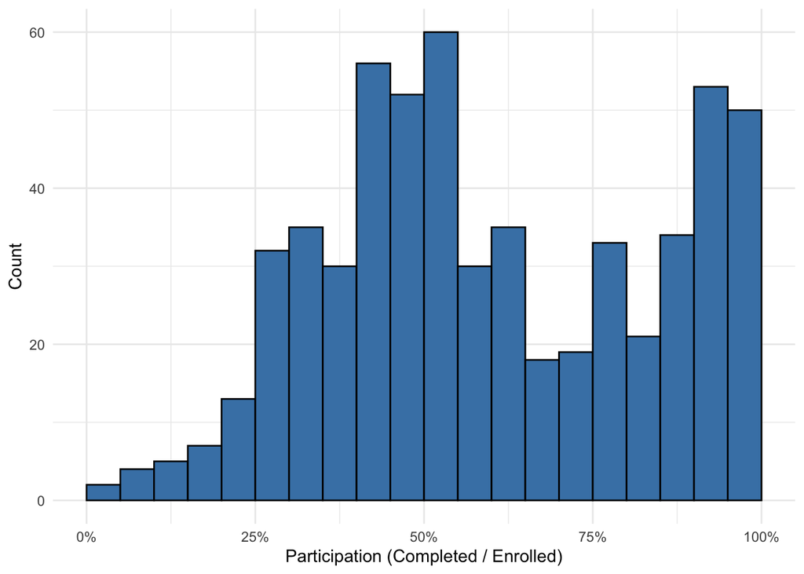

Figure 9: Distribution of Section Participation Rates.

## 6.2 Partispation rate by Course Type

The participation rate may also vary by course type. The average participation rate for each course type was calculated and visualized below.

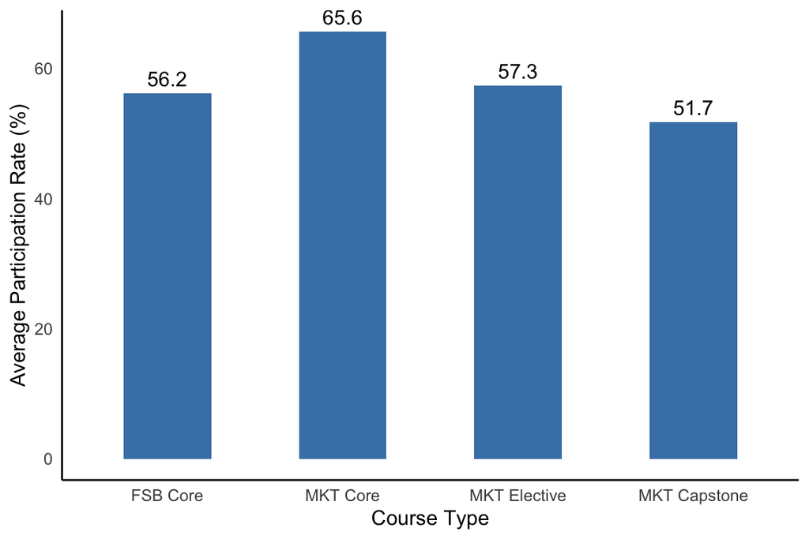

Figure 10: Average Participation Rate by Course Type.

Figure 10 shows participation differs across course types: MKT Core is highest (≈65.6%), followed by MKT Elective (≈57.3%) and FSB Core (≈56.2%), while MKT Capstone is lowest (≈51.7%). These gaps indicate systematic differences in response propensity by course type, which can induce response bias in unweighted ratings if low participation types are over or under represented.

## 6.3 Bar Chart of Teaching Performance Measures

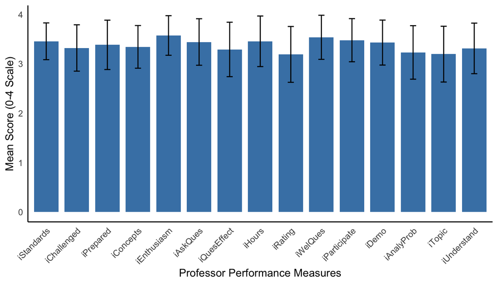

Figure 11: Mean Professor Performance Measures with Standard Deviation.

From Figure 11 and Table 4, professor performance measures generally have high mean scores, indicating positive evaluations from students. The measures with the highest means include iEnthusiasm (3.57), iWelQues (3.54), and iParticipate (3.48), suggesting that students perceive their instructors as enthusiastic, welcoming of questions, and encouraging participation.

However, the overall rating (iRating) has the lowest mean (3.19), suggesting that while specific aspects of teaching are rated highly, the overall evaluation is more moderate. The standard deviations indicate variability in student responses, with iRating showing one of the highest variabilities (0.56), reflecting the potential reason for the lower overall rating is the diversity of student structures and expectations.

## 6.4 Bar Chart of Student Behavior Measures

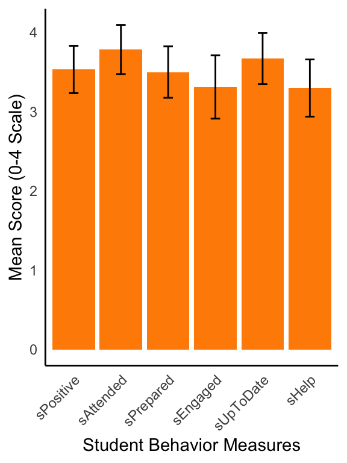

Figure 12: Mean Student Behavior Measures with Standard Deviation.

From Figure 12 and Table 4, student behavior measures also show generally high mean scores, indicating that students report positive engagement with their courses. The measures with the highest means include sAttended (3.78) and sUpToDate (3.67), suggesting that students are consistently attending classes and keeping up with coursework.

## 6.5 Visualize ceiling effect with density plot

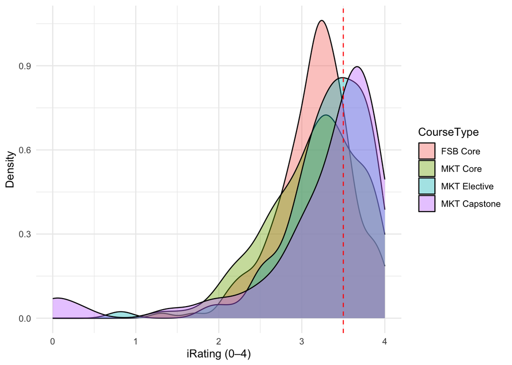

Figure 13: Density Plot of Overall Instructor Rating (iRating) by Course Type (Dashed = Ceiling Threshold 3.5).

## 6.6 Random Forest Regression Parameter Settings

Table 14: Random Forest Model Call Summary

| Parameter | Value |
| --- | --- |
| Number of Trees | 1000 |
| Mtry (variables per split) | 4 |
| Importance Measure | permutation |
| Case Weights Used | Completed (sum w = N) |
| OOB Prediction Error (MSE) | 0.0337 |
| OOB R-squared | 0.8943 |
| Training N | 589 |

Key model fit diagnostics:

## 6.7 An Alternative Method of Multicollinearity Control: LASSO

As a robustness check, LASSO regression was also applied to select professor performance items. The LASSO penalizes the absolute size of coefficients, shrinking some to zero and effectively performing variable selection.

Table 15: LASSO Selected Predictors and Coefficients

|  | Predictor | Coefficient |
| --- | --- | --- |
| 1 | (Intercept) | -0.8292174 |
| 5 | sEngaged | 0.0700491 |
| 9 | iChallenged | 0.1454021 |
| 10 | iPrepared | 0.1510395 |
| 14 | iQuesEffect | 0.2313212 |
| 16 | iWelQues | 0.0079972 |
| 17 | iParticipate | 0.1108519 |
| 18 | iDemo | 0.3518778 |
| 20 | iTopic | 0.1299840 |

In Table 15, the lasso results indicate that the most important predictors of overall instructor rating. The selected predictors and their coefficients are shown in the table above.

Table 16: VIFs for LASSO-Selected Predictors

| Variable | VIF | Flag |
| --- | --- | --- |
| iDemo | 10.046 | High |
| iWelQues | 9.468 | Moderate |
| iQuesEffect | 7.073 | Moderate |
| iParticipate | 6.905 | Moderate |
| iChallenged | 5.431 | Moderate |
| iPrepared | 4.188 | Acceptable |
| iTopic | 2.448 | Acceptable |
| sEngaged | 1.621 | Acceptable |

The VIFs in Table 16 for the LASSO selected predictors are still somewhat high, with one predictor (iDemo) exceeding 10, indicating high multicollinearity. Several others fall into the moderate range (5 < VIF < 10). Only three predictors have acceptable VIFs (≤ 5).

## 6.8 Model Comparison

Table 17: Likelihood Ratio Test Comparing Random Intercept vs Random Intercept and Random Slope Model

|  | npar | AIC | BIC | logLik | -2*log(L) | Chisq | Df | Pr(>Chisq) |
| --- | --- | --- | --- | --- | --- | --- | --- | --- |
| m1_ML | 8 | -343.1196 | -308.0921 | 179.5598 | -359.1196 | NA | NA | NA |
| m1_random_slope_ML | 29 | -360.3120 | -233.3376 | 209.1560 | -418.3120 | 59.19244 | 21 | 1.69e-05 |

## 6.9 Results of Models

Table 18: Fixed Effects Estimates with 95% CI for Model 1-2

| Term | Estimate | CI_Lower | CI_Upper | t_value | p_value | Significance |
| --- | --- | --- | --- | --- | --- | --- |
| (Intercept) | 3.173 | 3.148 | 3.198 | 247.505 | 0.0000 | *** |
| InstrQual_Z | 0.206 | 0.148 | 0.264 | 6.962 | 0.0000 | *** |
| Participate_Z | 0.047 | -0.002 | 0.096 | 1.861 | 0.0627 | . |
| Chall_Z | 0.084 | 0.040 | 0.129 | 3.714 | 0.0002 | *** |
| Prep_Z | 0.104 | 0.065 | 0.144 | 5.155 | 0.0000 | *** |
| Ques_Z | 0.186 | 0.129 | 0.243 | 6.425 | 0.0000 | *** |

Table 19: Fixed Effects Estimates with 95% CI for Model 2

| Term | Estimate | CI_Lower | CI_Upper | t_value | p_value | Significance |
| --- | --- | --- | --- | --- | --- | --- |
| (Intercept) | 3.173 | 3.149 | 3.198 | 251.336 | 0.0000 | *** |
| InstrQual_Z | 0.190 | 0.131 | 0.249 | 6.300 | 0.0000 | *** |
| Participate_Z | 0.046 | -0.003 | 0.094 | 1.840 | 0.0658 | . |
| Chall_Z | 0.070 | 0.025 | 0.115 | 3.044 | 0.0023 | ** |
| Prep_Z | 0.113 | 0.073 | 0.153 | 5.565 | 0.0000 | *** |
| Ques_Z | 0.190 | 0.135 | 0.245 | 6.782 | 0.0000 | *** |
| sEngaged_Z | 0.022 | -0.002 | 0.046 | 1.796 | 0.0724 | . |
| sPositive_Z | 0.018 | -0.007 | 0.044 | 1.399 | 0.1617 |  |

Table 20: Fixed Effects Estimates with 95% CI for Model 3

Estimate

CI_Lower

CI_Upper

t_value

p_value

Significance

(Intercept)

3.161

3.125

3.198

169.496

0.0000

***

InstrQual_Z

0.185

0.127

0.242

6.285

0.0000

***

Participate_Z

0.052

0.002

0.102

2.045

0.0409

Chall_Z

0.074

0.032

0.117

3.448

0.0006

***

Prep_Z

0.116

0.075

0.158

5.550

0.0000

***

Ques_Z

0.191

0.138

0.244

7.029

0.0000

***

sEngaged_Z

0.021

-0.004

0.046

1.634

0.1023

sPositive_Z

0.012

-0.014

0.039

0.917

0.3591

CourseTypeMKT Core

0.024

-0.017

0.065

1.161

0.2456

CourseTypeMKT Elective

-0.021

-0.075

0.033

-0.749

0.4540

CourseTypeMKT Capstone

0.055

-0.023

0.134

1.384

0.1665

Table 21: Fixed Effects Estimates with 95% CI for Model 4

Estimate

CI_Lower

CI_Upper

t_value

p_value

Significance

(Intercept)

3.152

3.111

3.193

150.305

0.0000

***

InstrQual_Z

0.254

0.146

0.363

4.588

0.0000

***

Participate_Z

0.104

0.004

0.203

2.034

0.0420

Chall_Z

-0.019

-0.093

0.056

-0.491

0.6234

Prep_Z

0.122

0.056

0.187

3.648

0.0003

***

Ques_Z

0.172

0.071

0.274

3.328

0.0009

***

sEngaged_Z

0.019

-0.030

0.067

0.757

0.4493

sPositive_Z

0.015

-0.033

0.063

0.626

0.5310

CourseTypeMKT Core

0.042

-0.003

0.088

1.824

0.0682

.

CourseTypeMKT Elective

-0.011

-0.071

0.050

-0.351

0.7256

CourseTypeMKT Capstone

0.083

-0.066

0.233

1.094

0.2742

InstrQual_Z:CourseTypeMKT Core

-0.112

-0.234

0.010

-1.801

0.0717

.

InstrQual_Z:CourseTypeMKT Elective

-0.004

-0.175

0.167

-0.045

0.9641

InstrQual_Z:CourseTypeMKT Capstone

-0.227

-0.365

-0.089

-3.218

0.0013

Participate_Z:CourseTypeMKT Core

-0.088

-0.208

0.031

-1.445

0.1486

Participate_Z:CourseTypeMKT Elective

-0.134

-0.298

0.030

-1.607

0.1081

Participate_Z:CourseTypeMKT Capstone

-0.026

-0.190

0.137

-0.316

0.7522

Chall_Z:CourseTypeMKT Core

0.130

0.038

0.221

2.779

0.0055

Chall_Z:CourseTypeMKT Elective

0.094

-0.019

0.207

1.629

0.1033

Chall_Z:CourseTypeMKT Capstone

0.244

0.099

0.388

3.304

0.0010

Prep_Z:CourseTypeMKT Core

0.017

-0.063

0.097

0.421

0.6737

Prep_Z:CourseTypeMKT Elective

-0.061

-0.162

0.041

-1.168

0.2428

Prep_Z:CourseTypeMKT Capstone

-0.026

-0.165

0.112

-0.374

0.7085

Ques_Z:CourseTypeMKT Core

0.019

-0.100

0.138

0.313

0.7541

Ques_Z:CourseTypeMKT Elective

0.087

-0.070

0.243

1.081

0.2797

Ques_Z:CourseTypeMKT Capstone

0.053

-0.100

0.206

0.679

0.4974

sEngaged_Z:CourseTypeMKT Core

0.029

-0.033

0.091

0.907

0.3643

sEngaged_Z:CourseTypeMKT Elective

-0.040

-0.104

0.025

-1.203

0.2292

sEngaged_Z:CourseTypeMKT Capstone

-0.103

-0.241

0.036

-1.453

0.1464

sPositive_Z:CourseTypeMKT Core

-0.035

-0.098

0.028

-1.085

0.2780

sPositive_Z:CourseTypeMKT Elective

0.049

-0.026

0.125

1.281

0.2002

sPositive_Z:CourseTypeMKT Capstone

0.030

-0.084

0.144

0.518

0.6046